# STATS 506 PS 3

Author

Jingyan Zhang

link to my GitHub repo: https://github.com/Menako2013529/STATS-506-Problem-Set

```r
library(haven)
library(dplyr)
library(knitr)
```

# Problem 1

I referred to ChatGPT for help reading .XPT files.

## a.

```r
# Load the datasets
vix_d <- read_xpt("VIX_D.XPT")
demo_d <- read_xpt("DEMO_D.XPT")

# Merge the datasets by SEQN, keeping only the matched records
merged_data <- inner_join(vix_d, demo_d, by = "SEQN")

sample_size <- nrow(merged_data)
cat("Total sample size: ", sample_size)
```

```
Total sample size:  6980
```

So the total sample size is now 6980, matched with the question requirement.

## b.

According to VIX_D documentation, VIQ220 represents whether tester wear glasses or contact lenses for distance vision, with 1 represents Yes, 2 represents No, 9 represents don’t know and NA represents missing values, shown below.

```r
unique(merged_data$VIQ220)
```

```
[1]  2 NA  1  9
```

According to DEMO_D documentation, RIDAGEYR represents the ages in years of testers.

```r
merged_data <- merged_data %>%
  mutate(age_bracket = cut(RIDAGEYR, breaks = seq(0, 100, by = 10),
                           right = FALSE,
                           labels = paste(seq(0, 90, by = 10),
                                          seq(9, 99, by = 10),
                                          sep = "-")))

proportion_data <- merged_data %>%
  group_by(age_bracket) %>%
  summarise(
    total = n(),
    wear_glasses = sum(VIQ220 == 1, na.rm = TRUE),
    proportion_wearing_glasses = wear_glasses / total
  )

# Round the results for better readability
proportion_data <- proportion_data %>%
  mutate(proportion_wearing_glasses = round(proportion_wearing_glasses, 2))

# Print the result
kable(proportion_data, caption = "Proportion of Respondents Wearing Glasses/Contacts for Distance Vision by Age Bracket", digits = 2)
```

Proportion of Respondents Wearing Glasses/Contacts for Distance Vision by Age Bracket

| age_bracket | total | wear_glasses | proportion_wearing_glasses |
| --- | --- | --- | --- |
| 10-19 | 2207 | 670 | 0.30 |
| 20-29 | 1021 | 306 | 0.30 |
| 30-39 | 818 | 269 | 0.33 |
| 40-49 | 815 | 286 | 0.35 |
| 50-59 | 631 | 335 | 0.53 |
| 60-69 | 661 | 392 | 0.59 |
| 70-79 | 469 | 299 | 0.64 |
| 80-89 | 358 | 208 | 0.58 |

## c.

According to DEMO_D documentation, RIDGEYR represents age, RIDRETH1 represents race, RIAGENDR represents gender and INDFMPIR represents poverty income ratio.

```r
# Remove NA missing values and map race and gender
data_clean <- merged_data %>%
  select(RIDAGEYR, RIDRETH1, RIAGENDR, INDFMPIR, VIQ220) %>%
  filter(!is.na(RIDAGEYR) & !is.na(RIDRETH1) & !is.na(RIAGENDR) & !is.na(INDFMPIR) & !is.na(VIQ220)) %>%
  mutate(RIAGENDR = recode(RIAGENDR, '1'="Male", '2'="Female"),
         RIDRETH1 = recode(RIDRETH1, '1'="Mexican American",
                                     '2'="Other Hispanic",
                                     '3'="Non-Hispanic White",
                                     '4'="Non-Hispanic Black",
                                     '5'="Other Race"),
         VIQ220 = recode(VIQ220, '1'=1, '2'=0,'9'=0))

# Ensure categorical variables are factors
data_clean <- data_clean %>%
  mutate(RIAGENDR = as.factor(RIAGENDR),
         RIDRETH1 = as.factor(RIDRETH1))
```

```r
unique(data_clean$VIQ220)
```

```
[1] 0 1
```

```r
library(pscl)
model_1 <- glm(VIQ220 ~ RIDAGEYR, data = data_clean, family = binomial)

model_2 <- glm(VIQ220 ~ RIDAGEYR + RIDRETH1 + RIAGENDR, data = data_clean, family = binomial)

model_3 <- glm(VIQ220 ~ RIDAGEYR + RIDRETH1 + RIAGENDR + INDFMPIR, data = data_clean, family = binomial)
```

```r
extract_model_info <- function(model) {
  model_summary <- broom::tidy(model, exponentiate = TRUE, conf.int = TRUE)

  # Get sample size, AIC, and pseudo-R²
  sample_size <- nobs(model)
  aic_value <- AIC(model)
  pseudo_r2 <- pscl::pR2(model)["McFadden"]

  # Add sample size, pseudo-R², and AIC to the output
  model_summary <- model_summary %>%
    mutate(Sample_Size = sample_size,
           Pseudo_R2 = pseudo_r2,
           AIC = aic_value)

  return(model_summary)
}

# Extract info for each model
model_1_info <- extract_model_info(model_1)
```

```
fitting null model for pseudo-r2
```

```r
model_2_info <- extract_model_info(model_2)
```

```
fitting null model for pseudo-r2
```

```r
model_3_info <- extract_model_info(model_3)
```

```
fitting null model for pseudo-r2
```

```r
results_table <- list(
  "Model 1 (Age)" = model_1_info,
  "Model 2 (Age, Race, Gender)" = model_2_info,
  "Model 3 (Age, Race, Gender, Poverty Ratio)" = model_3_info
)

# Display the results using kable
kable(bind_rows(results_table, .id = "Model"),
      caption = "Logistic Regression Results: Odds Ratios, Sample Size, Pseudo-R², and AIC",
      digits = 2)
```

Logistic Regression Results: Odds Ratios, Sample Size, Pseudo-R², and AIC

| Model | term | estimate | std.error | statistic | p.value | conf.low | conf.high | Sample_Size | Pseudo_R2 | AIC |
| --- | --- | --- | --- | --- | --- | --- | --- | --- | --- | --- |
| Model 1 (Age) | (Intercept) | 0.29 | 0.05 | -22.51 | 0.00 | 0.26 | 0.33 | 6249 | 0.05 | 8121.69 |
| Model 1 (Age) | RIDAGEYR | 1.02 | 0.00 | 19.55 | 0.00 | 1.02 | 1.03 | 6249 | 0.05 | 8121.69 |
| Model 2 (Age, Race, Gender) | (Intercept) | 0.27 | 0.08 | -17.29 | 0.00 | 0.23 | 0.32 | 6249 | 0.07 | 7951.26 |
| Model 2 (Age, Race, Gender) | RIDAGEYR | 1.02 | 0.00 | 17.26 | 0.00 | 1.02 | 1.03 | 6249 | 0.07 | 7951.26 |
| Model 2 (Age, Race, Gender) | RIDRETH1Non-Hispanic Black | 1.29 | 0.08 | 3.28 | 0.00 | 1.11 | 1.51 | 6249 | 0.07 | 7951.26 |
| Model 2 (Age, Race, Gender) | RIDRETH1Non-Hispanic White | 1.90 | 0.07 | 8.89 | 0.00 | 1.65 | 2.18 | 6249 | 0.07 | 7951.26 |
| Model 2 (Age, Race, Gender) | RIDRETH1Other Hispanic | 1.17 | 0.17 | 0.93 | 0.35 | 0.84 | 1.62 | 6249 | 0.07 | 7951.26 |
| Model 2 (Age, Race, Gender) | RIDRETH1Other Race | 1.89 | 0.14 | 4.57 | 0.00 | 1.44 | 2.47 | 6249 | 0.07 | 7951.26 |
| Model 2 (Age, Race, Gender) | RIAGENDRMale | 0.61 | 0.05 | -9.27 | 0.00 | 0.54 | 0.67 | 6249 | 0.07 | 7951.26 |
| Model 3 (Age, Race, Gender, Poverty Ratio) | (Intercept) | 0.22 | 0.08 | -18.28 | 0.00 | 0.19 | 0.26 | 6249 | 0.07 | 7912.08 |
| Model 3 (Age, Race, Gender, Poverty Ratio) | RIDAGEYR | 1.02 | 0.00 | 17.15 | 0.00 | 1.02 | 1.03 | 6249 | 0.07 | 7912.08 |
| Model 3 (Age, Race, Gender, Poverty Ratio) | RIDRETH1Non-Hispanic Black | 1.23 | 0.08 | 2.64 | 0.01 | 1.06 | 1.44 | 6249 | 0.07 | 7912.08 |
| Model 3 (Age, Race, Gender, Poverty Ratio) | RIDRETH1Non-Hispanic White | 1.65 | 0.08 | 6.69 | 0.00 | 1.43 | 1.92 | 6249 | 0.07 | 7912.08 |
| Model 3 (Age, Race, Gender, Poverty Ratio) | RIDRETH1Other Hispanic | 1.12 | 0.17 | 0.70 | 0.49 | 0.81 | 1.56 | 6249 | 0.07 | 7912.08 |
| Model 3 (Age, Race, Gender, Poverty Ratio) | RIDRETH1Other Race | 1.71 | 0.14 | 3.81 | 0.00 | 1.30 | 2.25 | 6249 | 0.07 | 7912.08 |
| Model 3 (Age, Race, Gender, Poverty Ratio) | RIAGENDRMale | 0.60 | 0.05 | -9.49 | 0.00 | 0.54 | 0.66 | 6249 | 0.07 | 7912.08 |
| Model 3 (Age, Race, Gender, Poverty Ratio) | INDFMPIR | 1.12 | 0.02 | 6.41 | 0.00 | 1.08 | 1.16 | 6249 | 0.07 | 7912.08 |

## d.

```r
kable(summary(model_3)$coefficients["RIAGENDRMale",] ,digits = 2)
```

|  | x |
| --- | --- |
| Estimate | -0.52 |
| Std. Error | 0.05 |
| z value | -9.49 |
| Pr(>\|z\|) | 0.00 |

The odds of men wearing glasses/contact lenses for distance vision are **significantly lower** than women, with a log-odds difference of -0.52. The corresponding p-value is less than 0.05, showing a significant difference in odds between men and women.

# Problem 2

## a.

```r
library(DBI)
library(RSQLite)
con <- dbConnect(RSQLite::SQLite(), "sakila_master.db")

query <- "
SELECT release_year, COUNT(*) AS movie_count
FROM film
WHERE release_year = (SELECT MIN(release_year) FROM film)
GROUP BY release_year;
"

result <- dbGetQuery(con, query)
print(result)
```

```
  release_year movie_count
1         2006        1000
```

## b.

(1) Using SQL

```r
query_genre <- "
SELECT category.name AS genre, COUNT(film_category.film_id) AS movie_count
FROM category
JOIN film_category ON category.category_id = film_category.category_id
GROUP BY genre
ORDER BY movie_count limit 1;
"

genre_data <- dbGetQuery(con, query_genre)
print(genre_data)
```

```
  genre movie_count
1 Music          51
```

(2) Using R

```r
least_common_genre <- genre_data[which.min(genre_data$movie_count), ]
print(least_common_genre)
```

```
  genre movie_count
1 Music          51
```

## c.

(1) Using SQL

```r
query_country_customers <- "
SELECT country.country AS country_name, COUNT(customer.customer_id) AS customer_count
FROM country
JOIN city ON country.country_id = city.country_id
JOIN address ON city.city_id = address.city_id
JOIN customer ON address.address_id = customer.address_id
GROUP BY country_name
HAVING customer_count = 13;
"
country_customers_data <- dbGetQuery(con, query_country_customers)
print(country_customers_data)
```

```
  country_name customer_count
1    Argentina             13
2      Nigeria             13
```

(2) Using R

```r
countries_with_13_customers <- country_customers_data[country_customers_data$customer_count == 13, ]

print(countries_with_13_customers)
```

```
  country_name customer_count
1    Argentina             13
2      Nigeria             13
```

# Problem 3

## a.

```r
us_500 <- read.csv("us-500.csv")
us_500 <- us_500 %>%
  mutate(domain = sub(".*@", "", email),  # Extract domain from email
         tld = sub(".*\\.", "", domain))

proportion_com <- us_500 %>%
  summarise(proportion = mean(tld == "com"))
print(proportion_com)
```

```
  proportion
1      0.732
```

## b.

I referred ChatGPT code.

```r
non_alphanumeric_pattern <- "[^a-zA-Z0-9@.]"

data <- us_500 %>%
  mutate(has_non_alphanumeric = grepl(non_alphanumeric_pattern, email))

proportion_non_alphanumeric <- data %>%
  summarise(proportion = mean(has_non_alphanumeric))

print(proportion_non_alphanumeric)
```

```
  proportion
1      0.248
```

## c.

```r
data <- us_500 %>%
  mutate(area_code = substr(gsub("[^0-9]", "", phone1), 1, 3))
top_area_codes <- data %>%
  group_by(area_code) %>%
  summarise(count = n()) %>%
  arrange(desc(count)) %>%
  head(5)

print(top_area_codes)
```

```
# A tibble: 5 × 2
  area_code count
  <chr>     <int>
1 973          18
2 212          14
3 215          14
4 410          14
5 201          12
```

The top 5 area codes are 973, 212, 215, 410 and 201.

## d.

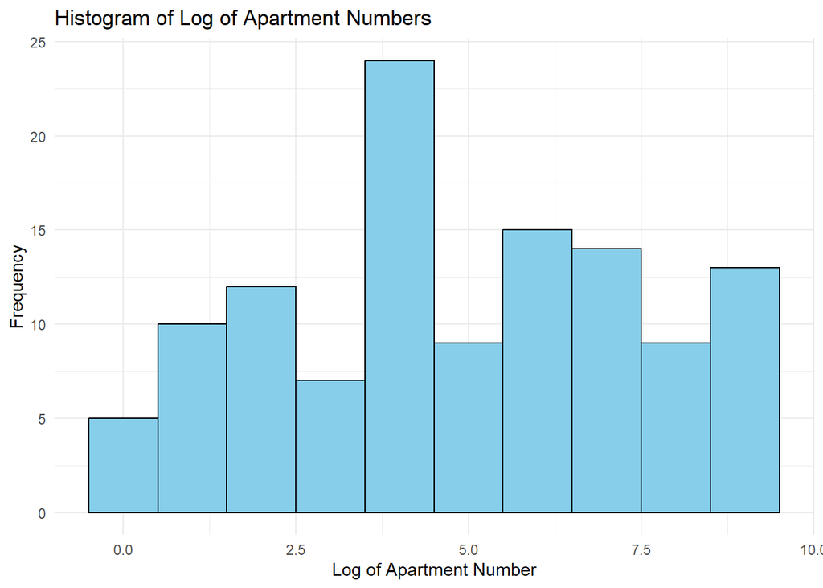

```r
library(ggplot2)
data <- us_500 %>%
  mutate(apartment_number = as.numeric(sub(".*[^0-9]([0-9]+)$", "\\1", address))) %>% na.omit()
data <- data %>%
  filter(!is.na(apartment_number))

data <- data %>%
  mutate(log_apartment_number = log(apartment_number))

ggplot(data, aes(x = log_apartment_number)) +
  geom_histogram(binwidth = 1, fill = "skyblue", color = "black") +
  labs(title = "Histogram of Log of Apartment Numbers", x = "Log of Apartment Number", y = "Frequency") +
  theme_minimal()
```

## e.

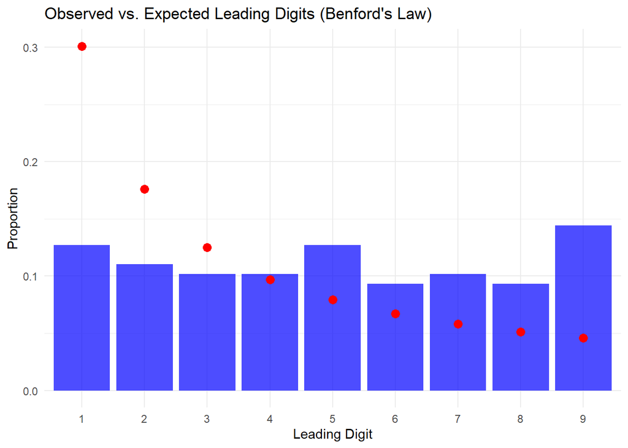

```r
data <- us_500 %>%
  mutate(apartment_number = as.numeric(sub(".*[^0-9]([0-9]+)$", "\\1", address))) %>%
  filter(!is.na(apartment_number)) %>%
  mutate(leading_digit = as.numeric(substr(apartment_number, 1, 1))) %>%
  na.omit()
observed_freq <- data %>%
  group_by(leading_digit) %>%
  summarise(count = n()) %>%
  mutate(observed_prob = count / sum(count))

# Benford's Law expected probabilities for digits 1 through 9
benford_prob <- tibble(
  leading_digit = 1:9,
  expected_prob = log10(1 + 1 / leading_digit)
)

# Merge the observed and expected probabilities
comparison <- left_join(observed_freq, benford_prob, by = "leading_digit") %>%
  mutate(expected_count = expected_prob * sum(count))



ggplot(comparison, aes(x = factor(leading_digit))) +
  geom_bar(aes(y = observed_prob), stat = "identity", fill = "blue", alpha = 0.7) +
  geom_point(aes(y = expected_prob), color = "red", size = 3) +
  labs(title = "Observed vs. Expected Leading Digits (Benford's Law)",
       x = "Leading Digit", y = "Proportion") +
  theme_minimal()
```

According to the proportion of leading digits and predicted proportion by Benford’s law, the apartment numbers appear not to follow Benford’s law, would not pass as real data.